# Ejercicio 1

```r
library(KernSmooth)
```

```r
breaks(s,0,0.06)
```

```
  [1]  1.68  1.74  1.80  1.86  1.92  1.98  2.04  2.10  2.16  2.22  2.28
 [12]  2.34  2.40  2.46  2.52  2.58  2.64  2.70  2.76  2.82  2.88  2.94
 [23]  3.00  3.06  3.12  3.18  3.24  3.30  3.36  3.42  3.48  3.54  3.60
 [34]  3.66  3.72  3.78  3.84  3.90  3.96  4.02  4.08  4.14  4.20  4.26
 [45]  4.32  4.38  4.44  4.50  4.56  4.62  4.68  4.74  4.80  4.86  4.92
 [56]  4.98  5.04  5.10  5.16  5.22  5.28  5.34  5.40  5.46  5.52  5.58
 [67]  5.64  5.70  5.76  5.82  5.88  5.94  6.00  6.06  6.12  6.18  6.24
 [78]  6.30  6.36  6.42  6.48  6.54  6.60  6.66  6.72  6.78  6.84  6.90
 [89]  6.96  7.02  7.08  7.14  7.20  7.26  7.32  7.38  7.44  7.50  7.56
[100]  7.62  7.68  7.74  7.80  7.86  7.92  7.98  8.04  8.10  8.16  8.22
[111]  8.28  8.34  8.40  8.46  8.52  8.58  8.64  8.70  8.76  8.82  8.88
[122]  8.94  9.00  9.06  9.12  9.18  9.24  9.30  9.36  9.42  9.48  9.54
[133]  9.60  9.66  9.72  9.78  9.84  9.90  9.96 10.02 10.08 10.14 10.20
[144] 10.26 10.32 10.38 10.44 10.50 10.56 10.62 10.68 10.74 10.80 10.86
[155] 10.92 10.98 11.04 11.10 11.16 11.22 11.28 11.34 11.40 11.46 11.52
```

[output cut: 41 more lines]

# Ejercicio 1.

Considérese la base de datos Boston Housing Data con información diversa sobre la vivienda en 506 barrios del área metropolitana de Boston en 1978 y que está disponible en el archivo BostonHousing de la R-librería mlbench. Se pide:

```r
data(BostonHousing)
```

[figure not shown]

```r
s
```

[output not shown]

[output cut: 31 more lines]

```r
bw.nrd(s); bw.ucv(s); bw.SJ(s)
```

[output not shown]

```r
contraejemplo <- s
bw.ucv(contraejemplo)
args(bw.ucv)
bw.ucv(contraejemplo, lower = 0.01, upper = 1)
bw.ucv.mod <- function(x, nb = 1000L,
                       h.grid = diff(range(x)) * (seq(0.1, 1, l = 200))^2,
                       plot.cv = FALSE) {
  if ((n <- length(x)) < 2L)
    stop("need at least 2 data points")
  n <- as.integer(n)
  if (is.na(n))
    stop("invalid length(x)")
  if (!is.numeric(x))
    stop("invalid 'x'")
  nb <- as.integer(nb)
  if (is.na(nb) || nb <= 0L)
    stop("invalid 'nb'")
  storage.mode(x) <- "double"
  hmax <- 1.144 * sqrt(var(x)) * n^(-1/5)
  Z <- .Call(stats:::C_bw_den, nb, x)
  d <- Z[[1L]]
  cnt <- Z[[2L]]
  fucv <- function(h) .Call(stats:::C_bw_ucv, n, d, cnt, h)
  obj <- sapply(h.grid, function(h) fucv(h))
  h <- h.grid[which.min(obj)]
  if (plot.cv) {
    plot(h.grid, obj, type = "o")
    rug(h.grid)
    abline(v = h, col = 2, lwd = 2)
  }
  h
}
bw.ucv.mod(contraejemplo, plot.cv = TRUE)
abline(v = bw.ucv(contraejemplo), col = 3)
```

[output not shown]

3. Proporcionar estimaciones puntuales de la densidad de probabilidad de lstat en los cuartiles muestrales usando el estimador de Rosenblat-Parzen con kernel de Epanechnikov y parámetro de suavizado h = 2.

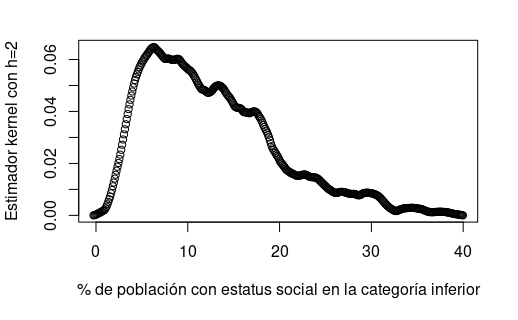

4. Valorar si el denominado “efecto frontera” está presente en los estimadores kernel generados en los epígrafes previos. Obtener el valor estimado de la densidad en lstat= 1.75 basado en
1. un estimador kernel y
2. la estimación kernel de los datos log-transformados y posterior transformación inversa. Explicar el segundo de los caminos y discutir los resultados.

[figure not shown]

```r
s.new <- log(s)
# Estimación nucleo datos transformados
tde <- density(s.new, window = "gaussian")   # Estimación de f_Y vía kernel
# Plot de la densidad kernel para los datos transformados (t(X)=log(X))
{hist(s.new,freq=FALSE,breaks=18,xlab="% de pob con estatus social baja",
     ylab=expression(paste("Estimador kernel  ", widehat(g[n]))),
     main="",col = "lightblue", border = "pink",cex.lab=1.2)
lines(tde, lwd = 2)
rug(s.new)}
```

```r
# Deshacemos la transformación
# Obtenemos los x en cuyos logaritmos se evalúa la densidad
# usando la transformación inversa (exponencial)
tinvde.x <- exp(tde$x)   #  x=t^{-1}(y)
# Obtenemos la densidad usando la regla de la cadena:
# Densidad basada en log(X_i) evaluada en tde$x por la derivada del logaritmo
tinvde.y <- tde$y * (1/tinvde.x)
# Plot simultáneo de histograma y densidad
{hist(s.new,freq=FALSE,breaks=15,xlab="% de pob con estatus social baja",
     ylab=expression(paste("Estimador densidad  ", widehat(f[n]))),
     main="",col = "lightblue", border = "pink",cex.lab=1.2, ylim=c(0,2))
rug(s.new)}
```

[output not shown]

5. Segmentar el archivo en dos grupos C1 y C2 caracterizados porque rm sea menor o mayor que su mediana muestral, respectivamente. Chequear analítica y gráficamente la hipótesis nula de que la densidad de la variable lstat es idéntica en ambos grupos.

```
Test of equal densities:  p-value =  0
```

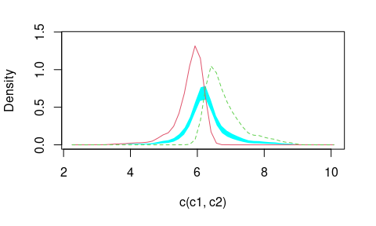

```r
sm.density.compare(c(c1,c2),g=rep(1:2, each=253),model="equal")
```

6. Estimar la densidad conjunta de (rm,lstat) y obtener su representación tridimensional y de líneas de contorno. Explicar brevemente cómo se ha construido este estimador.

```r
#Agrupamos falsos y reales en dos variables
b2 = cbind(BostonHousing$lstat,BostonHousing$rm)
colnames(b2) = c("lstat","rm")

# Ahora usamos la función bkde2D()
# El primer argumento es una matriz con dos columnas donde se ubican los datos
# Se considera el kernel bivariante Gaussiano reescalado por las dos ventanas
# que se introducen en el argumento "bandwidth" (usemos el plug-in directo SJ)
h1 <- dpik(b2[,1])
h2 <- dpik(b2[,2])
est <- bkde2D(b2, bandwidth = c(h1,h2))
# Gráfico de contorno de la densidad bivariante estimada:
contour(x = est$x1, y = est$x2, z = est$fhat,
        xlab = "Ancho margen inferior", ylab = "Longitud diagonal",
        cex.lab=1.2)
```

[output not shown]

```r
# Densidad estimada:
persp(x = est$x1, y = est$x2, z = est$fhat,
      xlab = "Ancho margen inferior", ylab = "Longitud diagonal",zlab="Densidad",
      cex.lab=.6, theta = -35, axes = TRUE, box = TRUE)
```

[output not shown]

7. Explorar el comportamiento de ajustes polinómicos de hasta orden dos para explicar el comportamiento de la variable rm (número medio de habitaciones por vivienda) como función de la variable lstat. Comparar su comportamiento con ajustes no paramétricos de tipo kernel: Nadaraya-Watson, Gasser-Müller, local lineal y local cúbico.

```r
summary(NW.h20)
```

```
  Length Class  Mode
x 506    -none- numeric
y 506    -none- numeric
```

[figure not shown]